# denguefevermodel

## Overview

Dengue Fever, caused by the Dengue Virus, infects millions of individuals in the regions of Asia, Africa, and the Americas, but is ubiquitous throughout the tropics. The disease is categorized as an epidemic in over 100 countries throughout Africa, the Americas, South-East Asia, the Western Pacific and the eastern Mediterranean. Symptoms of the virus may include typical fever symptoms as well as skin rashes, vomiting, and joint pain. In severe cases, the disease can cause blood complications – catalyzing the tens-of-thousands of deaths caused by the disease each year.

The infection is transmitted predominantly by mosquitos, which thrive in habitats with high moisture, warm temperatures, high vegetation, and still-bodies of water (puddles, marshes, swamps, lakes, pools, floodplains, ditches, etc.). One of the main concerns surrounding the spread of Dengue is that the pathogen spreads to additional vectors, such as rodents. Since 2010, analysts have described the spread of Dengue as “explosive”, and warned of a possible outbreak in Europe after reports of Dengue Fever in numerous European cities.

Factors that result in the spread of the virus can often be attributed to variables that affect mosquito populations, but other factors have also contributed to the increase in reported cases. Mosquitos lay their eggs in small bodies of water; any environmental or social changes that increase the breeding opportunities are expected to accelerate the number of viral infections. Increased temperatures, precipitation, humidity, and sea level caused by climate change can exacerbate the increasing threat of optimal mosquito breeding locations throughout the tropics. Independant variables related to mosquito that should be inspected include breeding include vegetation, precipitation, temperatures, time of day, and humidity.

Factors that are unrelated mosquito habitats can also be used to model the spread of Dengue fever. Globalization, population growth, and modernization have dramatically shaped the state of public health, in third world countries especially. Multiple factors that can be derived from population growth, including sanitation and proximity, increase the likelihood of transmission — and there for the spread — of Dengue Fever.

Since no vaccines exist, preventative measures are taken to limit exposure to mosquito bites. Some of the more effective measures include mosquito nets, the eradication of breeding habitats, insecticides and repellants, as well as staying indoors during the mid-morning and late afternoon. Currently, no reliable vaccine exists for the virus, but multiple partially-effective drugs are available.

A small percentage of Dengue cases result in extreme symptoms and are more likely to result in death. Some specialists speculate that these more severe cases are caused by a secondary infection of the same or a different strain of Dengue, after the individual has already experienced an infection. Because vaccines typically include a benign version of the virus, the use of partially-effective vaccines is frequently debated due to increased likelihood of an individual experiencing severe symptoms in the event that the individual is infected with a variant of the virus for a second time.

https://www.ncbi.nlm.nih.gov/pmc/articles/PMC3651993/#SD1

http://www.fao.org/docrep/009/a0789e/a0789e03.htm

https://ecdc.europa.eu/en/dengue-fever/facts/factsheet

https://towardsdatascience.com/predicting-dengue-spread-using-seasonal-arimax-model-on-meteorology-data-3f35979ec5d

https://www.drivendata.org/competitions/44/dengai-predicting-disease-spread/page/82/

## Set Up & Data Preparation

```python
# Import model and utilities
import pandas as pd
import numpy as np
from sklearn.model_selection import train_test_split # splitting data
from sklearn.neighbors import KNeighborsRegressor # regressor
from sklearn.neighbors import RadiusNeighborsRegressor # regressor
from sklearn.linear_model import LinearRegression # regressor
from sklearn.tree import DecisionTreeRegressor # regressor
from sklearn import svm # regressor
from sklearn.metrics import mean_absolute_error, make_scorer # scoring
from sklearn.preprocessing import MinMaxScaler # normalization
from sklearn.metrics import r2_score # validate model's accuracy
from sklearn.preprocessing import PolynomialFeatures # feature engineering & scaling
from sklearn.feature_selection import SelectPercentile
from sklearn.feature_selection import VarianceThreshold
from sklearn.model_selection import KFold
from sklearn.model_selection import cross_val_score
from sklearn.model_selection import GridSearchCV
from sklearn.pipeline import make_pipeline
import matplotlib.pyplot as plt

# Load data
data = pd.read_csv('./data/dengue_features_train.csv')
outcome = pd.read_csv('./data/dengue_labels_train.csv')

# Drop these columns for the following methods
# Unlike city and year, making dummy variables doesn't make much sense for these variables
data = data.drop(columns=['week_start_date','weekofyear', 'year'])
outcome = outcome.drop(columns=['weekofyear','city','year'])

# Fill missing values
data.fillna(method='ffill', inplace=True);
```

To prepare the data for modeling, the first step is to handle missing values. There are a handful of methods that can be utilized to accomplish this, but I chose to use a relatively simple approach and forward fill missing values. This means that missing values just adopt the respective value from the row above it. This is ideal for this dataset because there are relatively few missing values scattered randomly throughout the dataset. Additionally, the features of this dataset are mostly continuous and follow trends (climate data), so using the values from previous rows can give a good estimate of what that value would have been. This can cause problems with some datasets when there are long streaks of missing values; as values are copied from above, the accuracy of the estimate will decrease because it becomes further away from the last *recorded* value. I also removed some columns that caused problems while creating dummy values. For example, some of the features, like weekstartdate, were not continuous and not categorical and resulted in thousands of extra columns without any variance.

## Feature Engineering

```python
# Mosquitos eggs hatch within 48 hours and mature over the course of a week.
# Using a lagged-time variable for the precipitation might provide insight
# because the previous week's rainfall will have an impact on the
# breeding rate of the vector.

# Append the average vegetation index, calculated using the four directions
# provided
data['ndvi_avg'] = ((data.ndvi_se + data.ndvi_sw + data.ndvi_ne + data.ndvi_nw) / 4);

# Convert year and weekofyear to strings so that they get dummy columns
# data['year'] = data['year'].apply(str)

# Get dummy columns from categorical variables
data = pd.get_dummies(data);
```

Some additional steps I took to ensure that the features were optimized for modeling were to add some computed columns. At first added a lagged-time variable for the precipitation because mosquitos eggs hatch within 48 hours and mature over the course of a week. Using this might provide insight because the previous week's rainfall will have an impact on the breeding rate of the vector. This meant that one row had to be removed which made it very difficult to upload my results to DataDriven.org. Additionally, it was not selected by any of the models during grid search, so removing it was not likely to reduce prediction accuracy significantly. I did, however, compute the average vegetation index between the four directions around the city centroid. I suspect that the effectiveness of this new computed variable will depend on which city cases are being predicted for; additional climate features will play a role in how important the direction of the index is, especially wind magnitude and direction. Lastly, I created dummy variables for the remaining categorical features.

## Modeling

The first model that I chose to implement was a decision tree regressor. I chose to use this model first because it is easy to understand and visualize. Leveraging the functions that provide a printed tree structure, and the straight-forward parameters will allow me to analyze the results and use them to implement more complicated models more efficiently and effectively. This method produced predictions which were quite accurate, especially when using the maximum number of columns because this model does not require quantitative or numerical features. A grid search of the feasible parameters gave a decision tree regressor that used a maximum depth of 13 steps.

```python
# Modeling pipeline using a DecisionTreeRegressor.

# Split data into training and testing data
train_features, test_features, train_outcome, test_outcome = train_test_split(
    data,
    outcome,
    test_size=0.30,
)


# Object indicating how to fold the data
folds = KFold(n_splits=10, shuffle=True)

# Define a pipeline that will
# - Transform data using a MinMaxScaler
# - Fit a decision tree regressor
pipe = make_pipeline(PolynomialFeatures(),
                     #SelectPercentile(percentile=10),
                     MinMaxScaler(),
                     #VarianceThreshold(.1),
                     DecisionTreeRegressor()) # steps for each

# # Define a grid to search through and pass to grid search
params = {'polynomialfeatures__degree':range(1, 2),
          #'selectpercentile__percentile':range(10, 30, 5),
          'decisiontreeregressor__max_depth':range(5,50,1)}

grid_search = GridSearchCV(pipe, params, cv=folds, scoring=make_scorer(mean_absolute_error, greater_is_better=False));

grid_search.fit(train_features, train_outcome);
```

```
GridSearchCV(cv=KFold(n_splits=10, random_state=None, shuffle=True),
       error_score='raise',
       estimator=Pipeline(memory=None,
     steps=[('polynomialfeatures', PolynomialFeatures(degree=2, include_bias=True, interaction_only=False)), ('minmaxscaler', MinMaxScaler(copy=True, feature_range=(0, 1))), ('decisiontreeregressor', DecisionTreeRegressor(criterion='mse', max_depth=None, max_features=None,
           max_leaf_nodes=None,...lit=2, min_weight_fraction_leaf=0.0,
           presort=False, random_state=None, splitter='best'))]),
       fit_params=None, iid=True, n_jobs=1,
       param_grid={'polynomialfeatures__degree': range(1, 2), 'decisiontreeregressor__max_depth': range(5, 50)},
       pre_dispatch='2*n_jobs', refit=True, return_train_score='warn',
       scoring=make_scorer(mean_absolute_error, greater_is_better=False),
       verbose=0)
```

```python
decisiontree_preds = grid_search.predict(test_features);
```

Another familiar model that I used to predict cases of Dengue fever is K Nearest Neighbors. The parameters for this model are also quite simple. I used grid search to select the optimal number of neighbors. I started with a large range with large steps, then narrowed both of these values down so the model selects the right number of neighbors efficiently at a more granular level. This accuracy of this model also benefits from scaled features and the proper choice between uniform or distance based weighting, so I made sure to include those in the grid search.

```python
# Modeling pipeline using KNearestNeighbors.

# Split data into training and testing data
train_features, test_features, train_outcome, test_outcome = train_test_split(
    data,
    outcome,
    test_size=0.30,
);

# Object indicating how to fold the data
folds = KFold(n_splits=10, shuffle=True);

# Define a pipeline that will
# - Transform data using a MinMaxScaler
# - Fit a KNN regressor
pipe = make_pipeline(PolynomialFeatures(),
                     #SelectPercentile(percentile=10),
                     MinMaxScaler(),
                     #VarianceThreshold(.1),
                     KNeighborsRegressor()) # steps for each

# # Define a grid to search through and pass to grid search
params = {'polynomialfeatures__degree':range(1, 2),
          # 'selectpercentile__percentile':range(10, 30, 5),
          'kneighborsregressor__n_neighbors':range(5,21,1),
          'kneighborsregressor__weights':["uniform","distance"]}; # uniform has been consistently worse and doubles runtime

grid_search = GridSearchCV(pipe, params, cv=folds, scoring=make_scorer(mean_absolute_error, greater_is_better=False));

grid_search.fit(train_features, train_outcome.values.ravel());
```

[output not shown]

```python
knn_preds = grid_search.predict(test_features)
```

The model that produced the most accurate results at first was a simple linear regression. Despite searching through multiple levels across numerous variables, the optimal model used was quite simple: Single degree polynomial features, and one job did the trick.

```python
# Modeling pipeline using linear regression.

# Split data into training and testing data
train_features, test_features, train_outcome, test_outcome = train_test_split(
    data,
    outcome,
    test_size=0.30,
);

# Object indicating how to fold the data
folds = KFold(n_splits=10, shuffle=True)

# Define a pipeline that will
# - Transform data using a MinMaxScaler
# - Fit a linear regressor
pipe = make_pipeline(PolynomialFeatures(),
                     #SelectPercentile(percentile=10),
                     MinMaxScaler(),
                     #VarianceThreshold(.1),
                     LinearRegression()) # steps for each

# Define a grid to search through and pass to grid search
params = {'polynomialfeatures__degree':range(1, 3),
          #'selectpercentile__percentile':range(10, 30, 5),
          'linearregression__n_jobs':range(1,3,1)};

grid_search = GridSearchCV(pipe, params, cv=folds, scoring=make_scorer(mean_absolute_error, greater_is_better=False));

grid_search.fit(train_features, train_outcome.values.ravel());
```

```
GridSearchCV(cv=KFold(n_splits=10, random_state=None, shuffle=True),
       error_score='raise',
       estimator=Pipeline(memory=None,
     steps=[('polynomialfeatures', PolynomialFeatures(degree=2, include_bias=True, interaction_only=False)), ('minmaxscaler', MinMaxScaler(copy=True, feature_range=(0, 1))), ('linearregression', LinearRegression(copy_X=True, fit_intercept=True, n_jobs=1, normalize=False))]),
       fit_params=None, iid=True, n_jobs=1,
       param_grid={'polynomialfeatures__degree': range(1, 3), 'linearregression__n_jobs': range(1, 3)},
       pre_dispatch='2*n_jobs', refit=True, return_train_score='warn',
       scoring=make_scorer(mean_absolute_error, greater_is_better=False),
       verbose=0)
```

```python
linreg_preds = grid_search.predict(test_features)
```

```python
# Modeling pipeline using SVR.

# Split data into training and testing data
train_features, test_features, train_outcome, test_outcome = train_test_split(
    data,
    outcome,
    test_size=0.30,
);

# Object indicating how to fold the data
folds = KFold(n_splits=10, shuffle=True)

# Define a pipeline that will
# - Transform data using a MinMaxScaler
# - Fit a SV regressor
pipe = make_pipeline(PolynomialFeatures(),
                     #SelectPercentile(percentile=10),
                     MinMaxScaler(),
                     #VarianceThreshold(.1),
                     svm.SVR()) # steps for each

# # Define a grid to search through and pass to grid search
params = {'polynomialfeatures__degree':range(1, 2),
          # 'selectpercentile__percentile':range(10, 30, 5),
          'svr__kernel':['linear', 'poly', 'rbf']
         };

grid_search = GridSearchCV(pipe, params, cv=folds, scoring=make_scorer(mean_absolute_error, greater_is_better=False))

grid_search.fit(train_features, train_outcome.values.ravel());
```

```python
svr_preds = grid_search.predict(test_features)
```

## Validation & Visualization

At this point, we should have four separate sets of predictions; one for each model with optimized parameters. The accuracy of these be visualized by plotting the test results versus the predicted values. The model which had the lowest mean absolute error is SVR (which was 15, according to my measurements, not DrivenData’s), which is supported by the visualizations below:

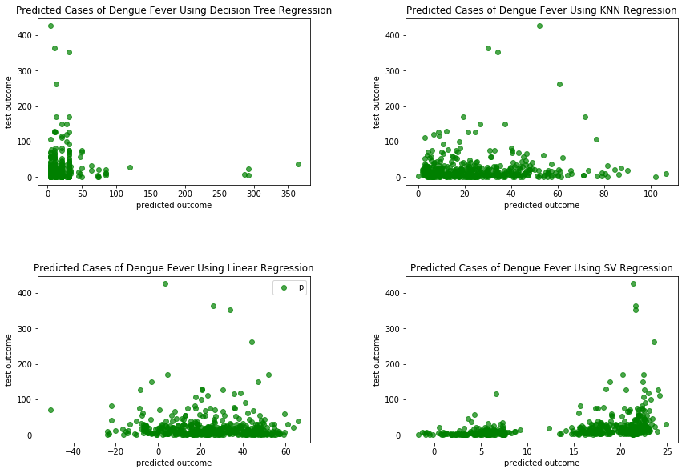

```python
# Make predictions and compare the scaled model
# preds = grid_search.predict(test_features)
# plt.scatter(preds, test_outcome)
# mean_absolute_error(preds, test_outcome)
# grid_search.cv_results_['params'][grid_search.best_index_]

plt.subplot(221)
plt.scatter(decisiontree_preds, test_outcome, alpha=0.7, c="green")
plt.title('Predicted Cases of Dengue Fever Using Decision Tree Regression')
plt.ylabel('test outcome')
plt.xlabel('predicted outcome')

plt.subplot(222)
plt.scatter(knn_preds, test_outcome, alpha=0.7, c="green")
plt.title('Predicted Cases of Dengue Fever Using KNN Regression')
plt.ylabel('test outcome')
plt.xlabel('predicted outcome')

plt.subplot(223)
plt.scatter(linreg_preds, test_outcome, alpha=0.7, c="green")
plt.title('Predicted Cases of Dengue Fever Using Linear Regression')
plt.ylabel('test outcome')
plt.xlabel('predicted outcome')

plt.subplot(224)
plt.scatter(svr_preds, test_outcome, alpha=0.7, c="green")
plt.title('Predicted Cases of Dengue Fever Using SV Regression')
plt.ylabel('test outcome')
plt.xlabel('predicted outcome')

# Adjust the subplot layout
plt.subplots_adjust(top=1.92, bottom=0.08, left=0.10, right=1.95, hspace=0.55, wspace=0.35);

plt.show()
```

One problematic insight is that all of the models appear to be underfitting the number cases of dengue fever in a given city in a given week. Diagnosing this problem is difficult, but the most likely culprit for this discrepancy is the number of folds used during cross validation; using a higher number of folds might have resulted in a model that gave more accurate results but is also more likely to overfit the data. The decision tree model was the most accurate of the four models, at first (I got a mean absolute error of 11). After integrating pipelines, cross validation, and changing the number of dummy variables, it ended up being the least accurate. To me, this indicated that this model is highly sensitive to the number of features. KNN and Linear Regression both gave me a mean absolute error of 18. The outcome vs. prediction plots for these two models are also very similar; they moth underfit the data and struggle to accurately estimate cases during weeks with a high number of actual occurrences. The linear regression model also resulted in some negative predicted counts, which does not make much sense in the context of Dengue Fever. The outliers in each model are typically weeks in which the number of cases of Dengue Fever are relatively high (greater than 100). Adding computed and dummy features, expanding the grid searching process, or looping through a range possible folds for cross validation are steps that could be taken to improve these models.

```python
# # Load *submission data* and predict
# submission_data = pd.read_csv('./data/dengue_features_test.csv')
# submission_data.fillna(method='ffill', inplace=True)

# prediction_data = submission_data
# prediction_data = prediction_data.drop(columns=['week_start_date','weekofyear', 'year'])

# # Append the average vegetation index, calculated using the four directions provided
# prediction_data['ndvi_avg'] = ((prediction_data.ndvi_se + prediction_data.ndvi_sw + prediction_data.ndvi_ne + prediction_data.ndvi_nw) / 4)

# # Get dummy columns from categorical variables
# prediction_data = pd.get_dummies(prediction_data)

# submission_data["total_cases"] = grid_search.predict(prediction_data).astype(np.int64)
# submission = submission_data[["city", "year", "weekofyear", "total_cases"]]
# submission.to_csv("./best_predictions.csv", index=False)
```